# Endophyte Erythromycin Diffusion Testing

Grace Carey

2023-02-10

## Introduction

The purpose of this document is to describe and visualize the results of the KB disk diffusion testing experiment on AMR STRIPS 2021 root endophytes.

## Prep

Read data file into R:

```
## Rows: 709
## Columns: 7
## $ PLATE_ID        <fct> C02_D1_R1_IS1_1A, C02_D1_R1_IS1_1B, C02_D1_R1_IS1_2A, …
## $ ZONE_mm         <dbl> 0, 0, 0, 0, 0, 0, 0, 0, 0, 0, 0, 0, 0, 0, 0, 0, 0, 0, …
## $ NOTES           <chr> "Slight phenotypic change", "Slight phenotypic change"…
## $ `DATE PLATED`   <chr> "4/4/23", "4/4/23", "4/4/23", "4/4/23", "4/4/23", "4/4…
## $ `DATE RECORDED` <chr> "4/5/23", "4/5/23", "4/5/23", "4/5/23", "4/5/23", "4/5…
## $ Column          <fct> C02, C02, C02, C02, C02, C02, C02, C02, C02, C02, C02,…
## $ Antibiotic      <fct> erythromycin, erythromycin, erythromycin, erythromycin…
```

```
## Rows: 54
## Columns: 7
## $ Column        <fct> C01, C02, C03, C04, C05, C06, C07, C08, C09, C10, C11, C…
## $ Treatment     <fct> Digestate, Mineral, Mineral, Manure, Manure, Manure, Dig…
## $ Column_Length <dbl> 35, 65, 35, 65, 35, 65, 35, 65, 35, 65, 35, 65, 35, 65, …
## $ Destruction   <dbl> 1, 3, 2, 2, 3, 1, 3, 2, 1, 3, 1, 2, 3, 1, 2, 1, 2, 3, 2,…
## $ X             <dbl> 1.0, 4.0, 1.5, 4.5, 1.0, 4.0, 2.0, 5.0, 2.5, 5.5, 2.0, 5…
## $ Y             <dbl> 1.0, 1.0, 1.5, 1.5, 2.0, 2.0, 1.0, 1.0, 1.5, 1.5, 2.0, 2…
## $ Block         <fct> Block 1, Block 1, Block 1, Block 1, Block 1, Block 1, Bl…
```

```
## Rows: 709
## Columns: 13
## $ PLATE_ID        <fct> C02_D1_R1_IS1_1A, C02_D1_R1_IS1_1B, C02_D1_R1_IS1_2A, …
## $ ZONE_mm         <dbl> 0, 0, 0, 0, 0, 0, 0, 0, 0, 0, 0, 0, 0, 0, 0, 0, 0, 0, …
## $ NOTES           <chr> "Slight phenotypic change", "Slight phenotypic change"…
## $ `DATE PLATED`   <chr> "4/4/23", "4/4/23", "4/4/23", "4/4/23", "4/4/23", "4/4…
## $ `DATE RECORDED` <chr> "4/5/23", "4/5/23", "4/5/23", "4/5/23", "4/5/23", "4/5…
## $ Column          <fct> C02, C02, C02, C02, C02, C02, C02, C02, C02, C02, C02,…
## $ Antibiotic      <fct> erythromycin, erythromycin, erythromycin, erythromycin…
## $ Treatment       <fct> Mineral, Mineral, Mineral, Mineral, Mineral, Mineral, …
## $ Column_Length   <dbl> 65, 65, 65, 65, 65, 65, 65, 65, 65, 65, 65, 65, 35, 35…
## $ Destruction     <dbl> 3, 3, 3, 3, 3, 3, 3, 3, 3, 3, 3, 3, 1, 1, 1, 1, 1, 1, …
## $ X               <dbl> 4.0, 4.0, 4.0, 4.0, 4.0, 4.0, 4.0, 4.0, 4.0, 4.0, 4.0,…
## $ Y               <dbl> 1.0, 1.0, 1.0, 1.0, 1.0, 1.0, 1.0, 1.0, 1.0, 1.0, 1.0,…
## $ Block           <fct> Block 1, Block 1, Block 1, Block 1, Block 1, Block 1, …
```

Column names:

| x |
| --- |
| PLATE_ID |
| ZONE_mm |
| NOTES |
| DATE PLATED |
| DATE RECORDED |
| Column |
| Antibiotic |
| Treatment |
| Column_Length |
| Destruction |
| X |
| Y |
| Block |

Samples were taken from the following columns:

Column Samples Plated

| C02 |
| --- |
| C09 |
| C28 |
| C35 |
| C37 |
| C49 |
| C23 |
| C30 |
| C46 |
| C41 |
| C21 |
| C26 |
| C38 |
| C27 |
| C42 |
| C18 |
| C36 |
| C25 |
| C33 |
| C39 |
| C19 |
| C32 |
| C03 |
| C48 |
| C04 |
| C53 |
| C01 |
| C43 |
| C52 |

These samples were plated using the standard Kirby-Bauer disk diffusion protocol. Disks were impregnated with 15ug erythromycin each. Two disks were placed on each plate, and each isolate was spread on two plates. For example, isolate C30_D1_R2_IS1_1 was plated twice: on plate C30_D1_R2_IS1_1 and on plate C30_D1_R2_IS1_2. Each plate contained two diffusion disk zones- zone A and zone B. So, zones C30_D1_R2_IS1_1A and C30_D1_R2_IS1_1B were the two zones taken from plate C30_D1_R2_IS1_1.

# Examining the Data

```
##       C02       C09       C28       C35       C37       C49       C23       C30
## 20.090909  0.000000 21.562500 24.734375  2.812500  0.000000 24.750000 24.500000
##       C46       C41       C21       C26       C38       C27       C42       C18
## 26.633333 28.578125 25.950000 26.575000 24.500000 28.386364 25.583333 29.750000
##       C36       C25       C33       C39       C19       C32       C03       C48
## 32.375000 32.000000 32.500000 35.500000 25.375000 24.916667  8.333333 26.437500
##       C04       C53       C01       C43       C52       C05       C06       C07
## 27.937500 25.741935  0.000000 26.500000 25.500000        NA        NA        NA
##       C08       C10       C11       C12       C13       C14       C15       C16
##        NA        NA        NA        NA        NA        NA        NA        NA
##       C17       C20       C22       C24       C29       C31       C34       C40
##        NA        NA        NA        NA        NA        NA        NA        NA
##       C44       C45       C47       C50       C51       C54
##        NA        NA        NA        NA        NA        NA
```

```
## Digestate   Mineral    Manure
##  15.25301  25.93939  22.17204
```

Standard Deviation and Mean for Zone Size (mm) by Column

| Column | sd | ZONE_mm |
| --- | --- | --- |
| C02 | 12.4859329 | 20.090909 |
| C09 | 0.0000000 | 0.000000 |
| C28 | 13.4498771 | 21.562500 |
| C35 | 6.8015922 | 24.734375 |
| C37 | 7.5623750 | 2.812500 |
| C49 | 0.0000000 | 0.000000 |
| C23 | 5.8002463 | 24.750000 |
| C30 | 7.4206918 | 24.500000 |
| C46 | 4.3190303 | 26.633333 |
| C41 | 4.9015860 | 28.578125 |
| C21 | 1.9208705 | 25.950000 |
| C26 | 1.6777198 | 26.575000 |
| C38 | 1.2909944 | 24.500000 |
| C27 | 4.1327726 | 28.386364 |
| C42 | 0.6685579 | 25.583333 |
| C18 | 0.5000000 | 29.750000 |
| C36 | 1.9958290 | 32.375000 |
| C25 | 1.6514456 | 32.000000 |
| C33 | 2.8867513 | 32.500000 |
| C39 | 1.2909944 | 35.500000 |
| C19 | 1.9959198 | 25.375000 |
| C32 | 1.1389036 | 24.916667 |
| C03 | 12.3091491 | 8.333333 |
| C48 | 1.4577380 | 26.437500 |
| C04 | 1.7215428 | 27.937500 |
| C53 | 1.1823068 | 25.741936 |
| C01 | 0.0000000 | 0.000000 |
| C43 | 0.5773503 | 26.500000 |
| C52 | 0.5773503 | 25.500000 |

Standard Deviation and Mean for Zone Size (mm) by Column Treatment

| Treatment | sd | ZONE_mm |
| --- | --- | --- |
| Digestate | 13.760588 | 15.25301 |
| Mineral | 8.264411 | 25.93939 |
| Manure | 10.026537 | 22.17204 |

Doing a one-way anova looking at the effect of Column ID on zone size:

```
##              Df Sum Sq Mean Sq F value Pr(>F)
## Column       28  65591  2342.5   68.59 <2e-16 ***
## Residuals   680  23223    34.2
## ---
## Signif. codes:  0 '***' 0.001 '**' 0.01 '*' 0.05 '.' 0.1 ' ' 1
```

Doing a one-way anova looking at the effect of column treatment on zone size:

```
##              Df Sum Sq Mean Sq F value Pr(>F)
## Treatment     2  11660    5830   53.35 <2e-16 ***
## Residuals   706  77154     109
## ---
## Signif. codes:  0 '***' 0.001 '**' 0.01 '*' 0.05 '.' 0.1 ' ' 1
```

Now we visualize zone sizes, by column ID, with error bars.

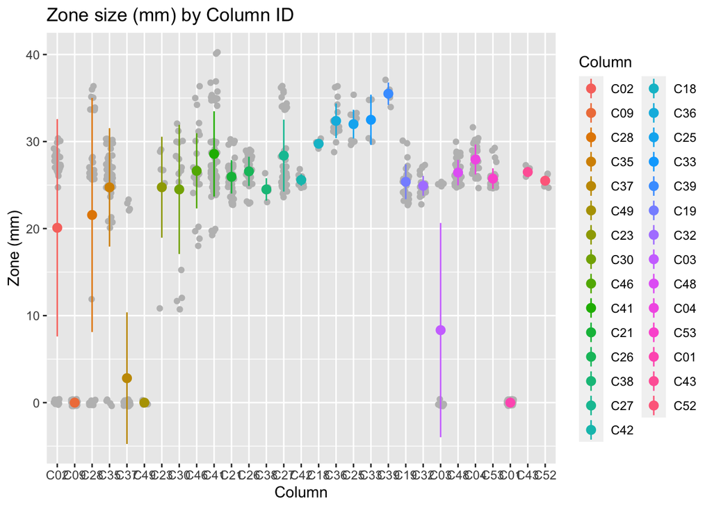

Now we visualize zone sizes, by treatment, with error bars.

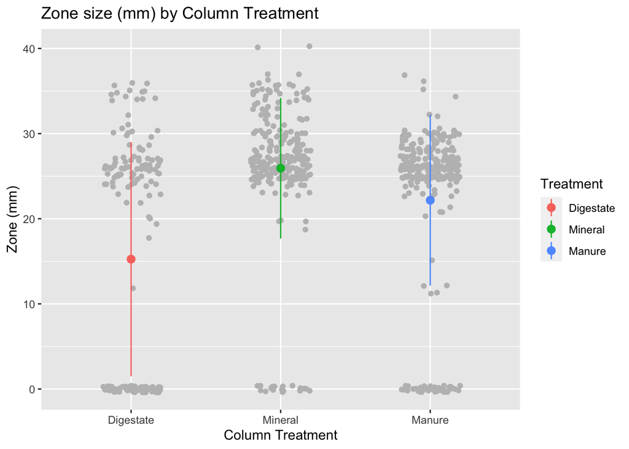

## Violin Plots

I think it might be interesting to see a violin plot of the data shown in the scatterplot. Especially considering that the digestate (at least as of 5/25/23) might have a higher number of 0mm zones (indicating no measured susceptibility to erythromycin).

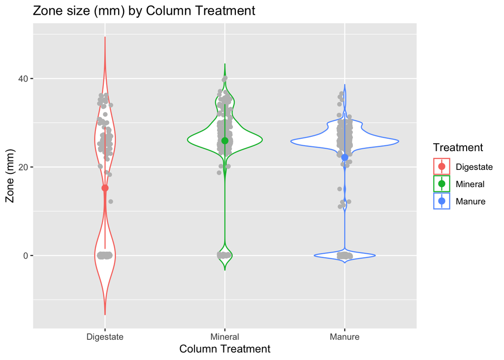

## Summary

To be continued. Please note that (as of 5/23/23) data and figures are using a demo (very incomplete) data set only. No conclusions can be made from current iteration.